# Tugas 4 APG

Bill Van Ricardo Zalukhu

2022-03-09

```r
library('MVN')
library('mvoutlier')
library('rcompanion')
library('caret')
library('openxlsx')
library('car')
library('RVAideMemoire')
```

Fungsi dari Hotelling’s T Distrbution

```r
T.test <- function(X, mu=0){
  X <- as.matrix(X)
  n <- nrow(X)
  p <- ncol(X)
  df2 <- n - p
  if(df2 < 1L) stop("Need nrow(X) > ncol(X).")
  if(length(mu) != p)
    mu <- rep(mu[1], p)
  xbar <- colMeans(X)
  S <- cov(X)
  T2 <- n * t(xbar - mu) %*% solve(S) %*% (xbar - mu)
  Fstat <- T2 / (p * (n-1) / df2)
  pval <- 1 - pf(Fstat, df1=p, df2=df2)
  data.frame(T2=as.numeric(T2), Fstat=as.numeric(Fstat), df1=p, df2=df2,
             p.value=as.numeric(pval), row.names="")
}
```

```r
data_first <- read.xlsx('C://Users//bilva//OneDrive//Documents//3SI1//Semester 6//Analisis Peubah Ganda//Tugas 4//Data_Y1.xlsx')
```

1. Mendefinisikan Vektor Rataan

```r
xbar_1 <- colMeans(data_first)
xbar_1
```

```
##    y1    y2
##  6.00 11.25
```

2. Melakukan Uji Hotelling’s T

```r
myu_first <- c(6, 11)
T.test(data_first, myu_first)
```

```
##          T2      Fstat df1 df2   p.value
##  0.06103286 0.02034429   2   2 0.9800613
```

3. Melakukan Penghitungan Nilai Statistik Uji dan `p-value`

```r
y_first <- as.matrix(data_first) - matrix(c(6, 11),nrow(data_first),ncol(data_first),byrow=T)
model_first<-anova(lm(y_first ~ 1))
model_first
```

```
## Analysis of Variance Table
##
##             Df   Pillai approx F num Df den Df Pr(>F)
## (Intercept)  1 0.019939 0.020344      2      2 0.9801
## Residuals    3
```

```r
n <- nrow(data_first)
p <- ncol(data_first)
alpha <- 0.05

CI <- (((n - 1)*p)/(n - p)) * qf(p = 1 - alpha, df1 = p, df2 = n - p)
CI
```

```
## [1] 57
```

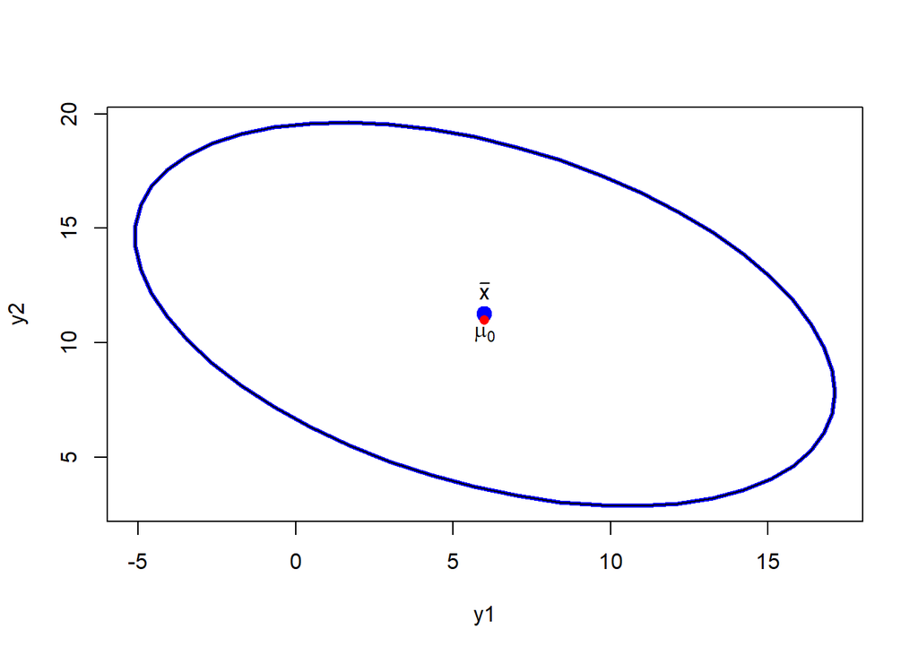

```r
n <- nrow(data_first)
p <- ncol(data_first)
S <- cov(data_first)
tconst <- sqrt((p/n)*((n-1)/(n-p)) * qf(1-alpha,p,n-p))
id <- c(1,2)
plot(ellipse(center=xbar_1[id], shape=S[id,id], radius=tconst, draw=F),type="n", xlab="y1", ylab="y2")
lines(ellipse(center=xbar_1[id], shape=S[id,id], radius=tconst, lwd=3), xlab="y1", ylab="y2")
points(6,11,col="red", pch = 16)
text(6,10.4,expression(mu[0]))
text(xbar_1[1],xbar_1[2]+1,expression(bar(x)))
```

Dari hasil pengujian hipotesis dan juga visualisai confidence region elipsoid nya diperoleh identifikasi bahwa nilai Hotteling’ s $T^{2}$ < nilai distribusi `F` nya, nilai `p-value` > 0.05, dan nilai dari $\mu_{0}$ nya berada `di dalam` area luasan elips. Dengan hasil tersebut, diperoleh bahwa hasil uji hipotesisnya adalah `gagal tolak H0`, sehingga dapat disimpulkan bahwa nilai dari rataan data `masih berada pada sekitaran rataan sebelumnya`.

```r
probe_words <- read.xlsx('C://Users//bilva//OneDrive//Documents//3SI1//Semester 6//Analisis Peubah Ganda//Tugas 4//Probe_Words.xlsx')
```

1. Mendefinisikan Vektor Rataan

```r
xbar_2 <- colMeans(probe_words)
xbar_2
```

```
##       y1       y2       y3       y4       y5
## 36.09091 25.54545 34.09091 27.27273 30.72727
```

2. Melakukan Uji Hotelling’s T

```r
myu_second <- c(30, 25, 40, 25, 30)
T.test(probe_words, myu_second)
```

```
##       T2    Fstat df1 df2     p.value
##  85.3327 10.23992   5   6 0.006699525
```

3. Melakukan Penghitungan Nilai Statistik Uji dan `p-value`

```r
y_second <- as.matrix(probe_words) - matrix(c(30, 25, 40, 25, 30),nrow(probe_words),ncol(probe_words),byrow=T)
model_second<-anova(lm(y_second ~ 1))
model_second
```

```
## Analysis of Variance Table
##
##             Df Pillai approx F num Df den Df Pr(>F)
## (Intercept)  1 0.8951    10.24      5      6 0.0067 **
## Residuals   10
## ---
## Signif. codes:  0 '***' 0.001 '**' 0.01 '*' 0.05 '.' 0.1 ' ' 1
```

```r
n <- nrow(probe_words)
p <- ncol(probe_words)
alpha <- 0.05

CI <- (((n - 1)*p)/(n - p)) * qf(p = 1 - alpha, df1 = p, df2 = n - p)
CI
```

```
## [1] 36.56145
```

```r
T.ci <- function(mu, Sigma, n, avec=rep(1,length(mu)), level=0.95){
  p <- length(mu)
  if(nrow(Sigma)!=p) stop("Need length(mu) == nrow(Sigma).")
  if(ncol(Sigma)!=p) stop("Need length(mu) == ncol(Sigma).")
  if(length(avec)!=p) stop("Need length(mu) == length(avec).")
  if(level <=0 | level >= 1) stop("Need 0 < level < 1.")
  cval <- qf(level, p, n-p) * p * (n-1) / (n-p)
  zhat <- crossprod(avec, mu)
  zvar <- crossprod(avec, Sigma %*% avec) / n
  const <- sqrt(cval * zvar)
  c(lower = zhat - const, upper = zhat + const) }
S<-cov(probe_words)
n <- nrow(probe_words)
p <- ncol(probe_words)
T.ci(mu=xbar_2, Sigma=S, n=n, avec=c(1,0,0,0,0))
```

```
##    lower    upper
## 21.38217 50.79965
```

```r
T.ci(mu=xbar_2, Sigma=S, n=n, avec=c(0,1,0,0,0))
```

```
##    lower    upper
## 13.17068 37.92023
```

```r
T.ci(mu=xbar_2, Sigma=S, n=n, avec=c(0,0,1,0,0))
```

```
##    lower    upper
## 19.88800 48.29381
```

```r
T.ci(mu=xbar_2, Sigma=S, n=n, avec=c(0,0,0,1,0))
```

```
##    lower    upper
## 12.82305 41.72240
```

```r
T.ci(mu=xbar_2, Sigma=S, n=n, avec=c(0,0,0,0,1))
```

```
##    lower    upper
## 16.81671 44.63784
```

```r
TCI <- tCI <- bon <- NULL
alpha1<-1-0.05
alpha2<-(0.05/2)
alpha3 <- 1 - 0.05/(2*5)
for(k in 1:5){
  avec <- rep(0, 5)
  avec[k] <- 1
  TCI <- c(TCI, T.ci(xbar_2, S, n, avec,level=alpha1))
  tCI <- c(tCI, xbar_2[k] - sqrt(S[k,k]/n) * qt(alpha2, df=n-1, lower.tail = F), xbar_2[k] + sqrt(S[k,k]/n) * qt(alpha2, df=n-1, lower.tail = F))
  bon <- c(bon, xbar_2[k] - sqrt(S[k,k]/n) * qt(alpha3, df=n-1), xbar_2[k] + sqrt(S[k,k]/n) * qt(alpha3, df=n-1))
}

rtab <- rbind(TCI, tCI, bon)
round(rtab, 2)
```

```
##     lower upper lower upper lower upper lower upper lower upper
## TCI 21.38 50.80 13.17 37.92 19.89 48.29 12.82 41.72 16.82 44.64
## tCI 30.67 41.51 20.99 30.11 28.86 39.32 21.95 32.60 25.60 35.85
## bon 28.38 43.80 19.06 32.03 26.65 41.54 19.70 34.85 23.44 38.02
```

Dari hasil pengujian hipotesis pada data `Probe Words` di atas, ternyata hasil dari uji hipotesis dengan simultaneous confidence memberikan hasil yang tidak sama (incosistent). Terlihat dari hasil pengujian hipotesis untuk per variabel, ternyata untuk variabel `y1` dan `y3` memiliki nilai $\mu_{0}$ yang berada di luar batas confidence interval. Hal ini bisa mengakibatkan terjadinya ketidakkonsistenan hasil pengujian hipotesis dari data `Probe Words` secara univariat dan multivariat.

3. 3.1. Melakukan Uji Hipotesis

```r
data_test <- read.xlsx('C://Users//bilva//OneDrive//Documents//3SI1//Semester 6//Analisis Peubah Ganda//Tugas 4//College_Test.xlsx')
```

1. Mendefinisikan Vektor Rataan

```r
xbar <- colMeans(data_test)
xbar
```

```
## social_science         verbal        science
##      526.58621       54.68966       25.01149
```

2. Melakukan Uji Hotelling’s T

```r
myu <- c(500, 50, 30)
T.test(data_test, myu)
```

```
##        T2    Fstat df1 df2 p.value
##  215.0576 70.01874   3  84       0
```

3. Melakukan Penghitungan Nilai Statistik Uji dan `p-value`

```r
y <- as.matrix(data_test) - matrix(c(500,50, 30),nrow(data_test),ncol(data_test),byrow=T)
model1<-anova(lm(y ~ 1))
model1
```

```
## Analysis of Variance Table
##
##             Df  Pillai approx F num Df den Df    Pr(>F)
## (Intercept)  1 0.71434   70.019      3     84 < 2.2e-16 ***
## Residuals   86
## ---
## Signif. codes:  0 '***' 0.001 '**' 0.01 '*' 0.05 '.' 0.1 ' ' 1
```

4. Menghitung Batas Confidence Interval

```r
n <- nrow(data_test)
p <- ncol(data_test)
alpha <- 0.05

CI <- (((n - 1)*p)/(n - p)) * qf(p = 1 - alpha, df1 = p, df2 = n - p)
CI
```

```
## [1] 8.333483
```

Dari hasil pengujian di atas, dapat kita lihat bahwa nilai dari `p-value` dengan kedua metode uji yang digunkan ternyata kurang dari nilai `alpha`, dan juga nilai hasil Hotelling’s $T^{2}$ lebih besar dari hasil uji `F`, sehingga dapat disimpulkan `tolak H0` yang mengartikan bahwa nilai rataan dari nilai test `Social Science, Verbal, dan Science` sudah tidak sama dengan nilai rataan sebelumnya.

3.2. Membuat Confidence Region Ellipsoid

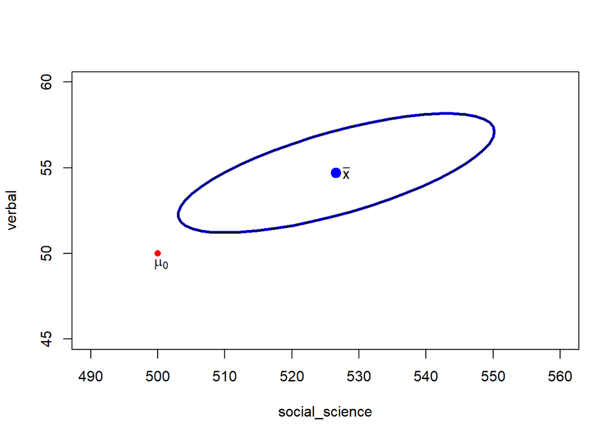

```r
n <- nrow(data_test)
p <- ncol(data_test)
S <- cov(data_test)
tconst <- sqrt((p/n)*((n-1)/(n-p)) * qf(1-alpha,p,n-p))
id <- c(1,2)
plot(ellipse(center=xbar[id], shape=S[id,id], radius=tconst, draw=F),type="n", xlab="social_science", ylab="verbal", ylim = c(45, 60), xlim = c(490, 560))
lines(ellipse(center=xbar[id], shape=S[id,id], radius=tconst, lwd=3), xlab="social_science", ylab="verbal")
points(500,50,col="red", pch = 16)
text(500.5,49.4,expression(mu[0]))
text(xbar[1]+1.5,xbar[2],expression(bar(x)))
```

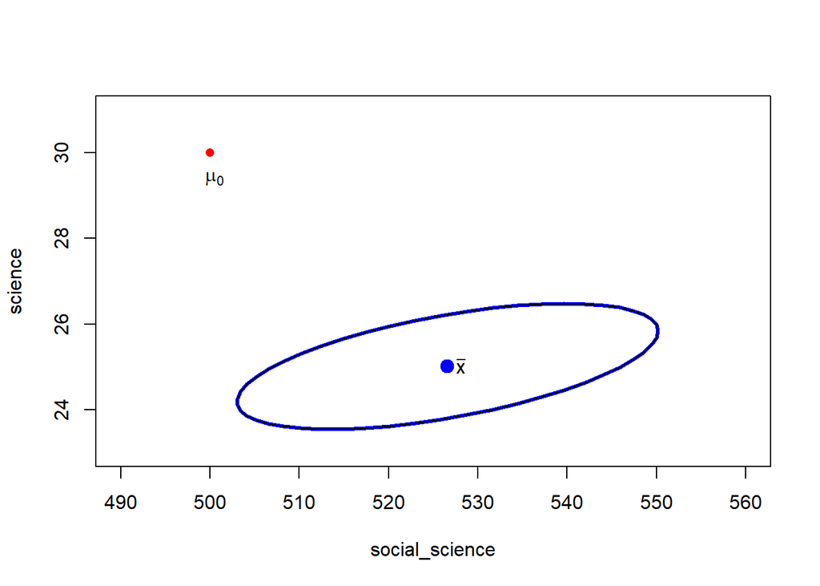

```r
n <- nrow(data_test)
p <- ncol(data_test)
S <- cov(data_test)
tconst <- sqrt((p/n)*((n-1)/(n-p)) * qf(1-alpha,p,n-p))
id <- c(1,3)
plot(ellipse(center=xbar[id], shape=S[id,id], radius=tconst, draw=F),type="n", xlab="social_science", ylab="science", ylim = c(23, 31), xlim = c(490, 560))
lines(ellipse(center=xbar[id], shape=S[id,id], radius=tconst, lwd=3), xlab="social_science", ylab="science")
points(500,30,col="red", pch = 16)
text(500.5,29.4,expression(mu[0]))
text(xbar[1]+1.5,xbar[3],expression(bar(x)))
```

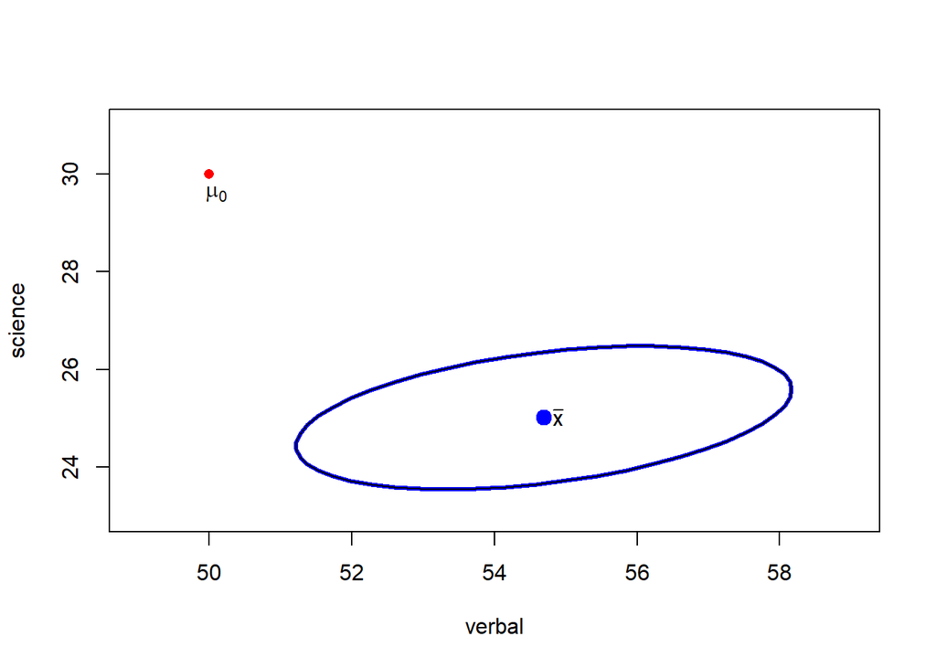

```r
n <- nrow(data_test)
p <- ncol(data_test)
S <- cov(data_test)
tconst <- sqrt((p/n)*((n-1)/(n-p)) * qf(1-alpha,p,n-p))
id <- c(2,3)
plot(ellipse(center=xbar[id], shape=S[id,id], radius=tconst, draw=F),type="n", xlab="verbal", ylab="science", xlim = c(49, 59), ylim = c(23, 31))
lines(ellipse(center=xbar[id], shape=S[id,id], radius=tconst, lwd=3), xlab="verbal", ylab="science")
points(50,30,col="red", pch = 16)
text(50.1,29.6,expression(mu[0]))
text(xbar[2]+.2,xbar[3],expression(bar(x)))
```

Dari hasil penggambaran elipsoid dari confidence region nya, ternyata hasilnya juga sama dengan hasil pengujian hipotesis sebelumnya, yaitu `tolak H0`.

3.3. Menghitung Confidence Simultaneous dengan Teknik Bonferoni

```r
bon <- NULL
alpha1 <-1-0.05
alpha2 <-1-(0.05/2)
alpha3 <- 1 - 0.05/(2*3)

for(k in 1:3){
  bon <- c(bon, xbar[k] - sqrt(S[k,k]/n) * qt(alpha3, df=n-1), xbar[k] + sqrt(S[k,k]/n) * qt(alpha3, df=n-1))
}

rtab <- rbind(bon)
round(rtab, 2)
```

```
##     social_science social_science verbal verbal science science
## bon         506.64         546.54  51.75  57.63   23.77   26.25
```

3.4. Melakukan Visualisasi Terhadap Data dengan Menggunakan `Q-Q Plot` dan `Chi-Square Plot`

1. Visualisasi Data dengan Menggunakan `Q-Q Plot`

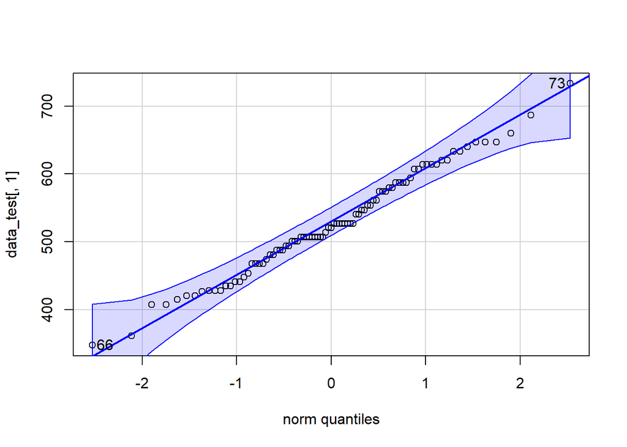

```
## [1] 73 66
```

```r
qqPlot(data_test[, 1])
```

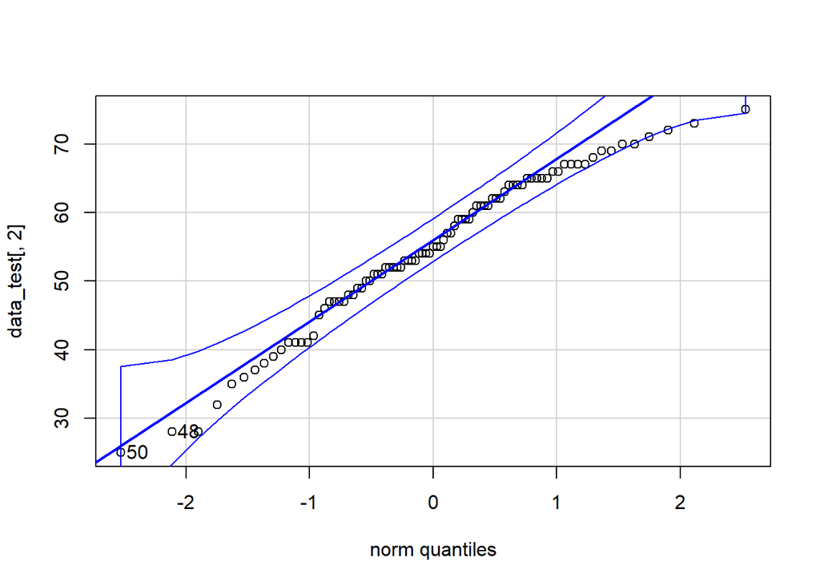

```
## [1] 50 48
```

```r
qqPlot(data_test[, 2])
```

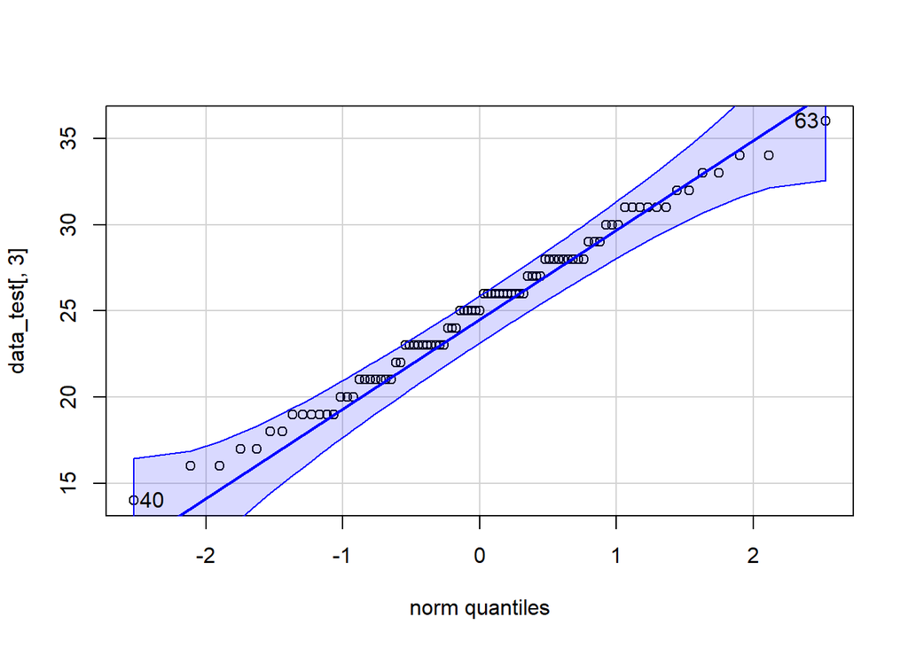

```
## [1] 40 63
```

```r
qqPlot(data_test[, 3])
```

2. Visualisasi dengan Menggunakan `Chi-Square Plot`

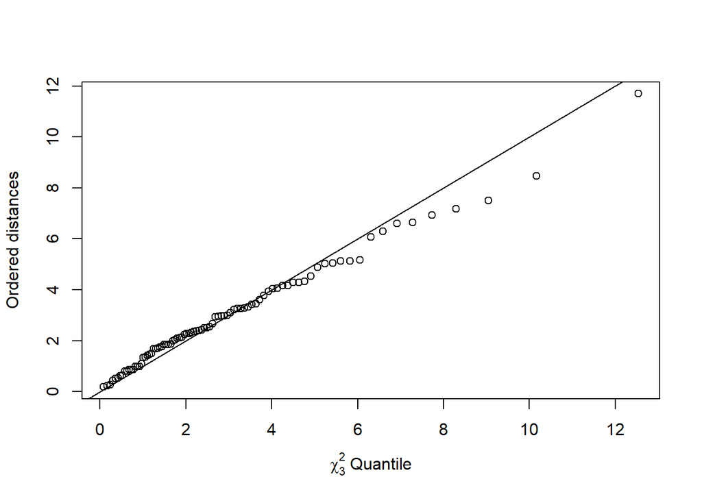

```r
xbarM <- colMeans(data_test)
S <- cov(data_test)
d <- apply(data_test, 1, function(data_test) t(data_test - xbarM) %*% solve(S) %*% (data_test - xbarM))
plot(qchisq((1:nrow(data_test) -1/2) / nrow(data_test), df =3), sort(d), xlab = expression(paste(chi[3]^2," Quantile")), ylab ="Ordered distances")
abline(a =0, b =1)
```

Dengan melihat hasil dari `qqnorm plot` setiap variabel dan `chi-square plot` dari data, terlihat bahwa data ternyata cenderung berada pada garis 45 derajat, yang mengindikasikan bahwa data berkemungkinan untuk berdistribusi normal. Dari hasil `chi-square plot` nya juga kita bisa melihat bahwa ada satu buah outlier dari kumpulan data tersebut.

3.5. Pengujian Multivariat Normal dari Data

- Mardia Test

```r
mvn(data_test, mvnTest = "mardia")
```

```
## $multivariateNormality
##              Test         Statistic          p value Result
## 1 Mardia Skewness  11.9915682440081 0.28562120312918    YES
## 2 Mardia Kurtosis -1.37260382772734 0.16987554130417    YES
## 3             MVN              <NA>             <NA>    YES
##
## $univariateNormality
##               Test       Variable Statistic   p value Normality
## 1 Anderson-Darling social_science    0.3890    0.3775    YES
## 2 Anderson-Darling     verbal        0.6931    0.0679    YES
## 3 Anderson-Darling    science        0.3714    0.4149    YES
##
## $Descriptives
##                 n      Mean   Std.Dev Median Min Max  25th  75th        Skew
## social_science 87 526.58621 76.210625    521 348 733 477.5 583.5  0.14152904
## verbal         87  54.68966 11.227365     55  25  75  48.0  64.0 -0.50839767
## science        87  25.01149  4.736043     25  14  36  21.0  28.0 -0.01877483
##                  Kurtosis
## social_science -0.3603633
## verbal         -0.3117746
## science        -0.6122864
```

- Henze-Zikler Test

```r
mvn(data_test)
```

```
## $multivariateNormality
##            Test        HZ   p value MVN
## 1 Henze-Zirkler 0.6014895 0.7625749 YES
##
## $univariateNormality
##               Test       Variable Statistic   p value Normality
## 1 Anderson-Darling social_science    0.3890    0.3775    YES
## 2 Anderson-Darling     verbal        0.6931    0.0679    YES
## 3 Anderson-Darling    science        0.3714    0.4149    YES
##
## $Descriptives
##                 n      Mean   Std.Dev Median Min Max  25th  75th        Skew
## social_science 87 526.58621 76.210625    521 348 733 477.5 583.5  0.14152904
## verbal         87  54.68966 11.227365     55  25  75  48.0  64.0 -0.50839767
## science        87  25.01149  4.736043     25  14  36  21.0  28.0 -0.01877483
##                  Kurtosis
## social_science -0.3603633
## verbal         -0.3117746
## science        -0.6122864
```

- Royston

```r
mvn(data_test, mvnTest = "royston")
```

```
## $multivariateNormality
##      Test        H   p value MVN
## 1 Royston 4.630966 0.1977454 YES
##
## $univariateNormality
##               Test       Variable Statistic   p value Normality
## 1 Anderson-Darling social_science    0.3890    0.3775    YES
## 2 Anderson-Darling     verbal        0.6931    0.0679    YES
## 3 Anderson-Darling    science        0.3714    0.4149    YES
##
## $Descriptives
##                 n      Mean   Std.Dev Median Min Max  25th  75th        Skew
## social_science 87 526.58621 76.210625    521 348 733 477.5 583.5  0.14152904
## verbal         87  54.68966 11.227365     55  25  75  48.0  64.0 -0.50839767
## science        87  25.01149  4.736043     25  14  36  21.0  28.0 -0.01877483
##                  Kurtosis
## social_science -0.3603633
## verbal         -0.3117746
## science        -0.6122864
```

- E-Statitics

```r
mvn(data_test, mvnTest = "energy")
```

```
## $multivariateNormality
##          Test Statistic p value MVN
## 1 E-statistic 0.7720545   0.686 YES
##
## $univariateNormality
##               Test       Variable Statistic   p value Normality
## 1 Anderson-Darling social_science    0.3890    0.3775    YES
## 2 Anderson-Darling     verbal        0.6931    0.0679    YES
## 3 Anderson-Darling    science        0.3714    0.4149    YES
##
## $Descriptives
##                 n      Mean   Std.Dev Median Min Max  25th  75th        Skew
## social_science 87 526.58621 76.210625    521 348 733 477.5 583.5  0.14152904
## verbal         87  54.68966 11.227365     55  25  75  48.0  64.0 -0.50839767
## science        87  25.01149  4.736043     25  14  36  21.0  28.0 -0.01877483
##                  Kurtosis
## social_science -0.3603633
## verbal         -0.3117746
## science        -0.6122864
```

- Multivariat Shapiro-Wilk

```r
mshapiro.test(data_test)
```

```
##
##  Multivariate Shapiro-Wilk normality test
##
## data:  (social_science,verbal,science)
## W = 0.97185, p-value = 0.05454
```

Dari hasil pengujian multivariat normal dari data, ternyata uji multivariat menunjukan hasil yang sama, yaitu data berdistribusi multivariat normal untuk semua uji. Dapat kita simpulkan bahwa data dari nilai test sebuah kampus ini memenuhi asumsi multivariat normal.